# Matplotlib Part 1. Installation and Introduction

## Part 1. Installation and Introduction

### Introduction

Matplotlib is a Python programming language plotting library. It's simple to use. It comes with an object-oriented API for integrating charts into apps. It includes many plots such as line, bar, scatter, histogram, and so forth.

Here is the link to [Matplotlib's Official Website](http://matplotlib.org/).

### Installation

If you have been using Python for a while you know that the simple way to install any Library/Package is:

**pip install [ package-name ]**

To Install Matplotlib:

**pip install matplotlib**

But, it is highly recommended that you download Python or any Python Packages through Anaconda. Below is the Link to Anaconda Installation guide.

[Anaconda Installation Guide](https://docs.anaconda.com/anaconda/install/windows/)

Anaconda contains most of the Libraries required for Data Science and Machine Learning so that you don't have to install them one by one. Once you install Anaconda, Matplotlib will already be present. If not, no need to worry, all you have to do is open the terminal and enter the below command:

**conda install matplotlib**

If you already have Matplotlib and want to upgrade use the below command.

**pip install matplotlib --upgrade**

or

**conda update matplotlib**

### Using Matplotlib

We will now look into, how to import Matplotlib.

In this tutorial you will learn:

1. Introduction and Installation
2. Basic Example using Matplotlib
3. Object Oriented approach for Matplotlib
4. Legends, Labels and Titles
5. Colors, Linewidths, Linetypes and Markers
6. Saving Figures

```python
import matplotlib
```

```python
# Check Version
matplotlib.__version__
```

```
'3.3.2'
```

```python
matplotlib.__path__
```

```
['D:\\ProgramFiles\\Anaconda\\lib\\site-packages\\matplotlib']
```

```python
# We use pyplot from matplotlib to plot figures

import matplotlib.pyplot as plt
```

### Examples of Plots

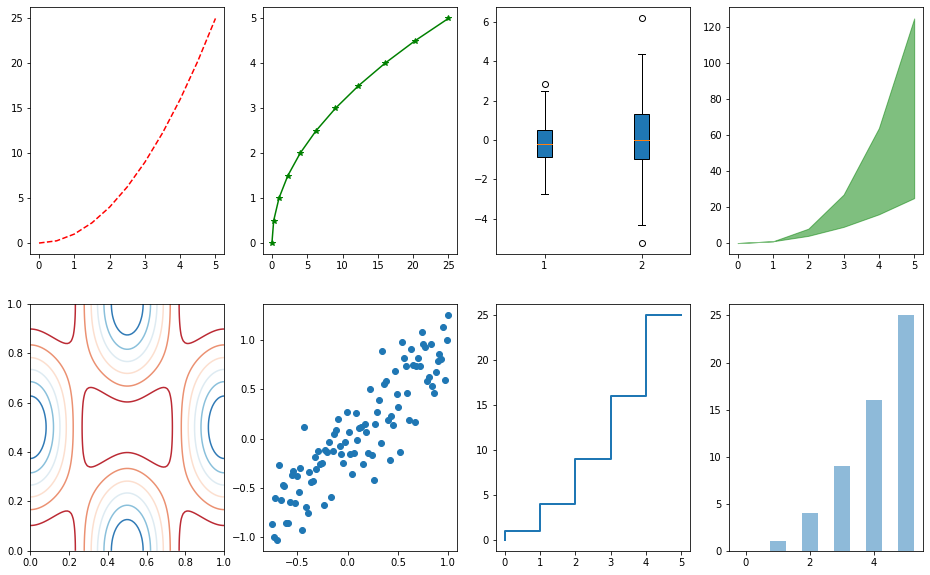

```python
import numpy as np

fig, axes = plt.subplots(2, 4, figsize=(16,10))

n = np.array([0,1,2,3,4,5])

xx = np.linspace(-0.75, 1., 100)

x = np.linspace(0, 5, 11)
y = x ** 2

axes[0][0].plot(x, y, 'r--')

axes[0][1].plot(y, x, 'g*-');

data = [np.random.normal(0, std, 100) for std in range(1, 3)]
axes[0][2].boxplot(data,vert=True,patch_artist=True);

axes[1][1].scatter(xx, xx + 0.25*np.random.randn(len(xx)))

axes[1][2].step(n, n**2, lw=2)

axes[1][3].bar(n, n**2, align="center", width=0.5, alpha=0.5)

axes[0][3].fill_between(n, n**2, n**3, color="green", alpha=0.5);

alpha = 0.7
phi_ext = 2 * np.pi * 0.5

def flux_qubit_potential(phi_m, phi_p):
    return 2 + alpha - 2 * np.cos(phi_p) * np.cos(phi_m) - alpha * np.cos(phi_ext - 2*phi_p)

phi_m = np.linspace(0, 2*np.pi, 100)
phi_p = np.linspace(0, 2*np.pi, 100)
X,Y = np.meshgrid(phi_p, phi_m)
Z = flux_qubit_potential(X, Y).T

axes[1][0].contour(Z, cmap=matplotlib.cm.RdBu, vmin=abs(Z).min(), vmax=abs(Z).max(), extent=[0, 1, 0, 1])

plt.show()
```

### And now you are good to go. Thank You